# Lunch & Learn - Python Automation

> - Basic Python Syntax
> - Jupyter Interactive
> - Automation
> - Jupyter's Magic Commands
> - Appendix

[figure not shown]

__Which environment are you currently working in?__

```python
!which python
```

```
/Users/aleksanderedemann/anaconda/bin/python
```

__What python version are you using?__

```python
!python --version
```

```
Python 3.6.1 :: Anaconda 4.4.0 (x86_64)
```

__Execute command line statements__

```python
cd
```

```
/Users/aleksanderedemann
```

```python
cd documents
```

```
/Users/aleksanderedemann/Documents
```

```python
ls
```

```
Automation/            Microsoft User Data/   RDC Connections/
Digital Editions/      Microsoft_Office_2011  Research/
L&L (WIP).ipynb        Nordea/
Loveit.txt             Parallels/
```

```python
cd -
```

```
/Users/aleksanderedemann
```

### Importing libraries

```python
import pandas as pd
import numpy as np
import datetime

import warnings
warnings.filterwarnings("ignore")
```

```python
from IPython.display import Image
```

You can use **sys.path** to display all the folders where Python will look when trying to import a module.

```python
import sys

sys.path
```

```
['',
 '/Users/aleksanderedemann/anaconda/lib/python36.zip',
 '/Users/aleksanderedemann/anaconda/lib/python3.6',
 '/Users/aleksanderedemann/anaconda/lib/python3.6/lib-dynload',
 '/Users/aleksanderedemann/anaconda/lib/python3.6/site-packages',
 '/Users/aleksanderedemann/anaconda/lib/python3.6/site-packages/Sphinx-1.5.6-py3.6.egg',
 '/Users/aleksanderedemann/anaconda/lib/python3.6/site-packages/aeosa',
 '/Users/aleksanderedemann/anaconda/lib/python3.6/site-packages/setuptools-27.2.0-py3.6.egg',
 '/Users/aleksanderedemann/anaconda/lib/python3.6/site-packages/IPython/extensions',
 '/Users/aleksanderedemann/.ipython']
```

If you can't find your module, but have it located on your pc then use **sys.path.append**

This may be useful where multiple python environments exist on a host.

```python
sys.path.append("/path/to/directory/containing/your/module")

import mymodule
```

pip install libraries directly from your Jupyter Notebook

```python
!pip install pandas
```

## Common Python Syntax

Press Tab after a dot to see what the library contains

[figure not shown]

When initializing function, put the cursor in the middle of the brackets and press Shift + Tab to get info

[figure not shown]

For first time users try the following: Note you use Ctrl + Enter to run a cell and Shift + Enter to run and jump to the next cell

[figure not shown]

#### Looping

```python
for i in range(0,5):
    print(i)
```

```
0
1
2
3
4
```

```python
names = ['Jesper','Mads','Panu','Alexandra','Mathias']

for i in names:
    print('Happy New Year: ' + i)
```

```
Happy New Year: Jesper
Happy New Year: Mads
Happy New Year: Panu
Happy New Year: Alexandra
Happy New Year: Mathias
```

```python
x = 0

while x < 5:

    print('Hello Nordea')

    x+=1
```

```
Hello Nordea
Hello Nordea
Hello Nordea
Hello Nordea
Hello Nordea
```

__Illustration of a While Loop:__

[figure not shown]

A Bit more Pythonic

```python
[x for x in range(0,5)]
```

```
[0, 1, 2, 3, 4]
```

```python
[x*x for x in range(0,5)]
```

```
[0, 1, 4, 9, 16]
```

```python
[x.upper() for x in 'Hello']
```

```
['H', 'E', 'L', 'L', 'O']
```

```python
[x.replace(',','') for x in ['these,,','wo,r,ds','have,','t,oo','many','c,omm,as']]
```

```
['these', 'words', 'have', 'too', 'many', 'commas']
```

```python
new_data = []

for i in range(0,5):
    new_data.append(i)
```

```python
new_data
```

```
[0, 1, 2, 3, 4]
```

```python
min(new_data)
```

```
0
```

```python
max(new_data)
```

```
4
```

Use a loop to write data to a txt fíle - Very useful

```python
f = open(r'H:\My documents\NEW_FILE.txt', 'w')

for i in range(0,5):
    f.write(str(i)+'\n')
f.close()
```

[figure not shown]

```python
Image(filename=r'C:\Users\G53283\Desktop\Lunch & Learn\notepad.png')
```

Add a progress bar to your loop

Note the time module is just included here to give a slow loop to show the progress bar

```python
from tqdm import tqdm, tqdm_notebook
import time

for i in tqdm_notebook(range(0,10)):
    time.sleep(1)
```

```
The installed widget Javascript is the wrong version.
```

### Conditional statements

```python
x = 8

if x > 4:
    print('True')
else:
    print('False')
```

```
True
```

```python
x = 6

if x > 4 and x < 10 :
    print('True')
else:
    print('False')
```

```
True
```

```python
Numbers = [1,2,3,4,5,6,7,8,9,10]

for i in Numbers:

    if i < 5:
        print(str(i)+' is less than 5')

    if i == 5:
        print(str(i)+' is equal to 5')

    if i > 5:
        print(str(i)+' is greater than 5')
```

```
1 is less than 5
2 is less than 5
3 is less than 5
4 is less than 5
5 is equal to 5
6 is greater than 5
7 is greater than 5
8 is greater than 5
9 is greater than 5
10 is greater than 5
```

```python
[x*x for x in range(0,10) if x < 10]
```

```
[0, 1, 4, 9, 16, 25, 36, 49, 64, 81]
```

```python
Image(filename='C:\Users\G53283\Desktop\Lunch & Learn\statements.png')
```

[output not shown]

### Slicing

```python
names = ['Jesper','Mads','Panu','Alexandra','Mathias']
```

```python
names[0]
```

```
'Jesper'
```

```python
names[-1]
```

```
'Mathias'
```

```python
names[3:5]
```

```
['Alexandra', 'Mathias']
```

```python
len(names)
```

```
5
```

```python
names[::-1]
```

```
['Mathias', 'Alexandra', 'Panu', 'Mads', 'Jesper']
```

```python
names.append('Zorro')
```

```python
names
```

```
['Jesper', 'Mads', 'Panu', 'Alexandra', 'Mathias', 'Zorro']
```

```python
'Zorro' in names
```

```
True
```

```python
iterator = iter(names)
```

```python
next(iterator)
```

```
'Jesper'
```

```python
next(iterator)
```

```
'Mads'
```

### Functions

```python
def multi(a,b):

    return a * b

multi(5,5)
```

```
25
```

```python
f = lambda x,y: x * y

f(5,5)
```

```
25
```

## Jupyter interactive

```python
h = raw_input('input your value ')
```

```
input your value 100
```

```python
print(h)
```

```
100
```

```python
name = raw_input('What is your name?\n')
```

```
What is your name?
Jesper
```

```python
print(name)
```

```
Jesper
```

```python
name = raw_input('Enter file:')
handle = open(name, 'r')
text = handle.read()
```

```
Enter file:C:\Users\G53283\Desktop\REPO.txt
```

```python
text
```

```
'Correction to CHF repo ON with Rene Hansen. Correction to DKK GOV and MORT ON TN with Dan Knudsen.  And correction to SEK GOV and MORT ON with Dan Knudsen. '
```

```python
while True:
    line = raw_input('> ')
    if line == 'done':
        break
    print (line)
print ('Done!')
```

```
> done
Done!
```

```python
from ipywidgets import *
from traitlets import dlink

def f(x):
    print(x * x)

interact(f, x=(0, 100));
```

```
2500
```

```python
from IPython.display import display

button = widgets.Button(description='Click to run SQL')
display(button)

def ifclicked(b):
    print("SQL is Running")

button.on_click(ifclicked)
```

```
The installed widget Javascript is the wrong version.
```

### Plotting

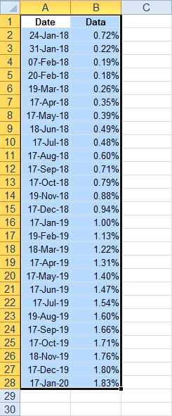

```python
Image(filename='C:\Users\G53283\Desktop\Lunch & Learn\Data.png')
```

#### The beauty of pandas read_clipboard()

```python
df = pd.read_clipboard()
df
```

|  | Date | Data |
| --- | --- | --- |
| 0 | 24-Jan-18 | 0.7185 |
| 1 | 31-Jan-18 | 0.2189 |
| 2 | 07-Feb-18 | 0.1929 |
| 3 | 20-Feb-18 | 0.1841 |
| 4 | 19-Mar-18 | 0.2608 |
| 5 | 17-Apr-18 | 0.3520 |
| 6 | 17-May-18 | 0.3908 |
| 7 | 18-Jun-18 | 0.4895 |
| 8 | 17-Jul-18 | 0.4785 |
| 9 | 17-Aug-18 | 0.6046 |
| 10 | 17-Sep-18 | 0.7062 |
| 11 | 17-Oct-18 | 0.7875 |
| 12 | 19-Nov-18 | 0.8761 |
| 13 | 17-Dec-18 | 0.9404 |
| 14 | 17-Jan-19 | 1.0021 |
| 15 | 19-Feb-19 | 1.1297 |
| 16 | 18-Mar-19 | 1.2218 |
| 17 | 17-Apr-19 | 1.3133 |
| 18 | 17-May-19 | 1.3954 |
| 19 | 17-Jun-19 | 1.4715 |
| 20 | 17-Jul-19 | 1.5378 |
| 21 | 19-Aug-19 | 1.6038 |
| 22 | 17-Sep-19 | 1.6566 |
| 23 | 17-Oct-19 | 1.7068 |
| 24 | 18-Nov-19 | 1.7555 |
| 25 | 17-Dec-19 | 1.7959 |
| 26 | 17-Jan-20 | 1.8350 |

```python
df.head()
```

|  | Date | Data |
| --- | --- | --- |
| 0 | 24-Jan-18 | 0.7185 |
| 1 | 31-Jan-18 | 0.2189 |
| 2 | 07-Feb-18 | 0.1929 |
| 3 | 20-Feb-18 | 0.1841 |
| 4 | 19-Mar-18 | 0.2608 |

```python
df.tail()
```

|  | Date | Data |
| --- | --- | --- |
| 22 | 17-Sep-19 | 1.6566 |
| 23 | 17-Oct-19 | 1.7068 |
| 24 | 18-Nov-19 | 1.7555 |
| 25 | 17-Dec-19 | 1.7959 |
| 26 | 17-Jan-20 | 1.8350 |

```python
df['Timestwo']  = df['Data'] * 2
```

```python
df.head()
```

|  | Date | Data | Timestwo |
| --- | --- | --- | --- |
| 0 | 24-Jan-18 | 0.7185 | 1.4370 |
| 1 | 31-Jan-18 | 0.2189 | 0.4378 |
| 2 | 07-Feb-18 | 0.1929 | 0.3858 |
| 3 | 20-Feb-18 | 0.1841 | 0.3682 |
| 4 | 19-Mar-18 | 0.2608 | 0.5216 |

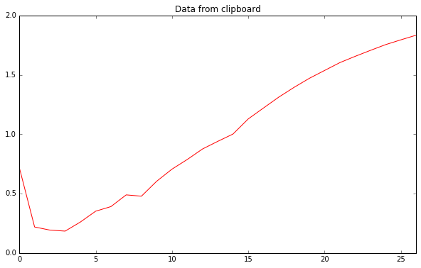

```python
%matplotlib inline

df['Data'].plot(figsize=(10,6), color='red', title='Data from clipboard')
```

## Automation

#### Run SQL with Marvin

```python
from marvin import marvin_cfg
from pandas.tseries.offsets import BDay

twp = marvin_cfg.get_connection('twp') #get connection to TWP
trmp = marvin_cfg.get_connection('trmp') #get connection to TRMP

Today = datetime.datetime.today().strftime("%d-%m-%y")
Yesterday_B = (datetime.datetime.today()-BDay(1)).strftime("%d-%m-%y")
```

#### Read SQL

```python
df = pd.read_sql("""select fa_date, contract, strike, maturity, portfolio, data, vega, pl_vega, spread, bid, ask, mid, fa
from fcuser.ibcno_voltool_log
where fa_date = TO_DATE('"""+Today+"""','DD/MM/YY')
and abs(PL_VEGA) >= 10000
and abs((mid- fa)) > 0.01
and abs((mid- fa)) / spread > 1
and data <> 'Parameterization'
and spread <> 0
""", trmp)

df
```

|  | fa_date | contract | strike | maturity | portfolio | data | vega | pl_vega | spread | bid | ask | mid | fa |
| --- | --- | --- | --- | --- | --- | --- | --- | --- | --- | --- | --- | --- | --- |
| 0 | 2018-01-16 | IYRUP19A80 | 80 | 43483 | SEDT DEVON | Market data | 32873.507086 | 50046.142989 | 0.00909 | 0.143785 | 0.152875 | 0.14833 | 0.133106 |

#### Save SQL result to Excel sheet

```python
df.to_excel(r'H:\My documents\EXAMPLE.xlsx') #write the dataframe to excel
df.to_csv(r'H:\My documents\EXAMPLE.csv') #write the dataframe to csv
```

[figure not shown]

```python
Image(filename='C:\Users\G53283\Desktop\Lunch & Learn\Excel example.png')
```

Read the Saved result into Python from your csv and excel file

```python
df1 = pd.read_excel(r'H:\My documents\EXAMPLE.xlsx') #write the dataframe to excel
df2 = pd.read_csv(r'H:\My documents\EXAMPLE.csv') #write the dataframe to csv
```

```python
df1
```

|  | fa_date | contract | strike | maturity | portfolio | data | vega | pl_vega | spread | bid | ask | mid | fa |
| --- | --- | --- | --- | --- | --- | --- | --- | --- | --- | --- | --- | --- | --- |
| 0 | 2018-01-16 | IYRUP19A80 | 80 | 43483 | SEDT DEVON | Market data | 32873.507086 | 50046.142989 | 0.00909 | 0.143785 | 0.152875 | 0.14833 | 0.133106 |

#### Execute a SQL script

```python
twp.execute("""DECLARE
     P_DATE DATE;
     P_GLOGON VARCHAR2(200);
     BEGIN
     P_DATE := TO_DATE('"""+Yesterday_B+"""','DD/MM/YY');
     P_GLOGON := 'G53283';
     IPV.PKG_IPV_EQUITY.load_equity_t1 (  P_DATE => P_DATE,P_GLOGON => P_GLOGON) ;
     END;""")

print('Done')
```

[output not shown]

### Interact with other programs with win32com

This is an API for controlling windows programs such as Excel, Word, Outlook etc.

#### <font color = 'darkblue'> Open Notepad </font>

```python
import win32com.client as win32
from win32com.client import Dispatch
import pyautogui
import time

shell = win32.Dispatch("WScript.Shell") #Open Shell
shell.Run("notepad") #Open Notepad
time.sleep(2)
shell.AppActivate("Notepad") #Run Notepad
```

If you want to open it on a specific screen use the following

```python
win = pyautogui.getWindow('Notepad')
win.maximize()
win.move(0,0)
win.set_foreground()
```

#### Open Google Chrome

```python
shell = win32.Dispatch("WScript.Shell") #Open Shell
shell.Run("Chrome") #Open Chrome
time.sleep(1) #Sleep in order to get the computer to catch up
shell.AppActivate("Chrome")#Activate Chrome
```

```
True
```

If you want to open it on a specific screen use the following

```python
win = pyautogui.getWindow('Chrome')
win.maximize()
win.move(0,0)
win.set_foreground()
```

Alternatively with use of webbrowser

```python
import webbrowser

webbrowser.open('http://www.livescore.com/')
```

```
True
```

#### Interact with MS Office with win32com.client (Very VBAish)

MS Office allows for access through the Common Object Model (COM) interfaces

```python
import win32com
import win32com.client

xl = win32com.client.Dispatch("Excel.application")
xl.visible = true
```

If everything went okay, then an empty instance of Excel should have appeared on your screen. What we’ve done is import the win32 COM modules (lines 1,2), created a COM dispatch object ‘xl’ that is bound to the ‘Excel.application’ in line 4 (the text is case insensitive by the way).

Finally, we reach into the xl object, and change the ‘visible’ property to true, which makes it appear.

Powerpoint and Word (and probably the other office tools with VBA but most people are only interested in these anyways) can be accessed with:

```python
ppt = win32com.client.Dispatch("Powerpoint.application")
```

```python
word = win32com.client.Dispatch("Word.application")
```

Working with Excel

```python
import win32com
import win32com.client

xl = win32com.client.Dispatch("excel.application")

xl.visible = True #make the application visible

xl.WorkBooks.Add() #call the WorkBook collection, and tell it to Add a new one.

book = xl.ActiveWorkBook #store the current active workbook (the one we added) as book

book.ActiveSheet.Name = "mySheet" #set the name of the active worksheet 'Sheet1' to 'mySheet'

book.Activesheet.Range("A1").value = 100  #put 100 into the cell "A1"

#then we can close the book
book.close() #this will prompt Excel to ask you about saving the edited file.
```

Closing Excel

```python
xl = win32com.client.Dispatch("Excel.Application")
xl.Quit() #quit excel, as if user hit the close button/clicked file->exit.

# -- OR --
xl.ActiveWorkBook.Close #close the active workbook
xl.DisplayAlerts = False #force excel to not display alerts
xl.Quit() #then quit the app
del xl #we delete the xl object, allowing python to let go of the COM reference, allowing the Excel process to close finally.
```

What if you want to open an existing file?

```python
xl = win32.gencache.EnsureDispatch('Excel.Application')
wb = xl.Workbooks.Open('filename')
```

The Excel object hierarchy basically goes Application, Workbook, Sheet, Range, Cell.

```python
import win32com.client

xl = win32com.client.Dispatch("Excel.Application")
data = xl.Range("A1").value  #active book, active sheet
data2 = xl.Sheets("Sheet2").Range("A1").value #active book, specific sheet
data3 = xl.WorkBooks(2).Sheets("Sheet3").Cells(1,1).value #specific book, specific sheet
```

Working with ranges and cells

```python
import win32com.client as win32

excel = win32.gencache.EnsureDispatch('Excel.Application')

wb = excel.Workbooks.Add()
ws = wb.Worksheets("Sheet1")

ws.Cells(1,1).Value = "Cell A1"
ws.Cells(1,1).Offset(2,4).Value = "Cell D2"

ws.Range("A2").Value = "Cell A2"
ws.Range("A3:B4").Value = "A3:B4"

ws.Range("A6:B7,A9:B10").Value = "A6:B7,A9:B10"

wb.SaveAs('ranges_and_offsets.xlsx')
excel.Application.Quit()
```

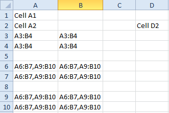

```python
Image(filename=r'C:\Users\G53283\Desktop\Lunch & Learn\ranges.png')
```

```python
xl.Range("A1").FormulaR1C1 = "=c[1]+c[2]"
xl.Range("A1").Copy
xl.Range("A2:A9000").Paste
```

```python
xlSheet.Cells(4,1).Formula = '=A2*2'
```

Empty cells are represented by the Python value None

```python
xlSheet.Cells(1,1).Value = None # clear a cell
xlSheet.Cells(1,1).Value # returns None
```

Using Python Loops in Excel

```python
import win32com.client as win32

excel = win32.gencache.EnsureDispatch('Excel.Application')

wb = excel.Workbooks.Add()
ws = wb.Worksheets("Sheet1")

for i in range(1,10):
    ws.Cells(1,i).Value = i

wb.SaveAs('loops.xlsx')
excel.Application.Quit()
```

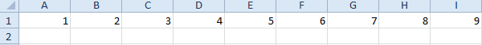

```python
Image(filename=r'C:\Users\G53283\Desktop\Lunch & Learn\loops.png')
```

Work with Colors

```python
import win32com.client as win32

excel = win32.gencache.EnsureDispatch('Excel.Application')

wb = excel.Workbooks.Add()
ws = wb.Worksheets("Sheet1")

for i in range (1,21):
    ws.Cells(i,1).Value = i
    ws.Cells(i,1).Interior.ColorIndex = i

wb.SaveAs('cell_color.xlsx')
excel.Application.Quit()
```

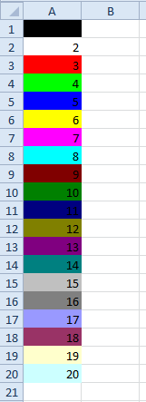

```python
Image(filename=r'C:\Users\G53283\Desktop\Lunch & Learn\colors.png')
```

Work with Formats

```python
import win32com.client as win32
excel = win32.gencache.EnsureDispatch('Excel.Application')

wb = excel.Workbooks.Add()
ws = wb.Worksheets("Sheet1")

for i,font in enumerate(["Arial","Courier New","Garamond","Georgia","Verdana"]):
    ws.Range(ws.Cells(i+1,1),ws.Cells(i+1,2)).Value = [font,i+i]
    ws.Range(ws.Cells(i+1,1),ws.Cells(i+1,2)).Font.Name = font
    ws.Range(ws.Cells(i+1,1),ws.Cells(i+1,2)).Font.Size = 12+i

ws.Range("A1:A5").HorizontalAlignment = win32.constants.xlRight

ws.Range("B1:B5").NumberFormat = "$###,##0.00"

ws.Columns.AutoFit()

wb.SaveAs('format_cells.xlsx')
excel.Application.Quit()
```

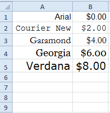

```python
Image(filename=r'C:\Users\G53283\Desktop\Lunch & Learn\formats.png')
```

Refresh Excel Sheet without seeing eg. Visible = 0

```python
import win32com.client

Application = win32com.client.Dispatch("Excel.Application")
Application.Visible = 0 #Set to 1 if you want to see the sheet - like VBAs screen updating

Workbook = Application.Workbooks.Open(r'H:\Book1.xlsx')
Workbook.RefreshAll()
Workbook.Save()
Workbook.Close()

Application.Quit()
```

Write VBA Code From Python - Note with this you can loop a VBA code to mulitple workbooks

```python
from win32com.client import DispatchEx

vba =  """
Sub Hello()

Range("A1:A2").value = 1

End Sub
"""

xl = DispatchEx('Excel.Application')
wb = xl.Workbooks.Add('H:\Book1.xlsx')

mod = wb.VBProject.VBComponents.Add(1)
mod.CodeModule.AddFromString(vba)

xl.Run('Hello')
wb.SaveAs('H:\Book1111.xlsm',FileFormat=52)
xl.Quit()
```

```python
Image(filename='C:\Users\G53283\Desktop\Lunch & Learn\VBA example.png')
```

[output not shown]

Run VBA Code From Python with xlwings

```python
import xlwings
wb = xlwings.Book('Q:\$PC_Global_Rates\RPO & MD\Market Data\Valuation\Daily Controls\FLD Upload\FLD macro.xlsm')
macro = wb.macro('sbDelete_Rows_IF_Cell_Is_Blank') #name of the macro
macro.run()
```

```python
from win32com.client import Dispatch as comDispatch

xl = comDispatch('Excel.Application')
xl.Workbooks.Open("Macros.xls", False, True)
xl.Run("Macros.xls!Macro_1")
```